# Example R and Stata code for a Mendelian randomization analysis

Sanderson et al.

20 March 2023

## R code

- Read in the data

```r
library(tidyverse)
library(haven)
library(remotes)

dat <- read_dta("https://raw.github.com/remlapmot/mrrobust/master/dodata.dta")
dat <- dat %>% filter(ldlcp2 < 1e-8)
```

### Example code using the MendelianRandomization package

- Install the package and load it into memory

```r
library(MendelianRandomization)
```

- Convert our data frame to the required class

```r
datfmt <- mr_mvinput(
  bx = as.matrix(cbind(dat$ldlcbeta, dat$hdlcbeta, dat$tgbeta)),
  bxse = as.matrix(cbind(dat$ldlcse, dat$hdlcse, dat$tgse)),
  by = dat$chdbeta,
  byse = dat$chdse,
  exposure = "exposure",
  outcome = "outcome",
  snps = "snp",
  effect_allele = dat$a1,
  other_allele = dat$a2,
  eaf = NA
)
```

- Fit an MVMR/MVIVW model

```r
mvivwfit <- mr_mvivw(datfmt)
mvivwfit
```

```
##
## Multivariable inverse-variance weighted method
## (variants uncorrelated, random-effect model)
##
## Number of Variants : 73
##
## ------------------------------------------------------------------
##    Exposure Estimate Std Error  95% CI       p-value
##  exposure_1    0.429     0.061  0.309, 0.548   0.000
##  exposure_2   -0.194     0.131 -0.451, 0.062   0.138
##  exposure_3    0.226     0.123 -0.016, 0.468   0.067
## ------------------------------------------------------------------
## Residual standard error =  1.490
## Heterogeneity test statistic = 155.3766 on 70 degrees of freedom, (p-value = 0.0000)
```

- Fit an MVMR-Egger model

```r
mvmreggerfit <- mr_mvegger(datfmt)
mvmreggerfit
```

```
##
## Multivariable MR-Egger method
## (variants uncorrelated, random-effect model)
##
## Orientated to exposure : 1
## Number of Variants : 73
## ------------------------------------------------------------------
##     Exposure Estimate Std Error  95% CI       p-value
##   exposure_1    0.567     0.100  0.371, 0.764   0.000
##   exposure_2   -0.136     0.133 -0.398, 0.125   0.306
##   exposure_3    0.274     0.125  0.030, 0.518   0.028
##  (intercept)   -0.009     0.005 -0.020, 0.001   0.084
## ------------------------------------------------------------------
## Residual standard error =  1.469
## Heterogeneity test statistic = 148.9290 on 69 degrees of freedom, (p-value = 0.0000)
```

### Example code using the MVMR and RMVMR packages

- Install the package and load it into memory

```r
if (!requireNamespace("MVMR", quietly = TRUE)) {
  remotes::install_github("WSpiller/MVMR")
}
library(MVMR)
```

- Create a data object of the required structure

```r
r_input <- format_mvmr(
  BXGs = dat[,c("ldlcbeta","hdlcbeta","tgbeta")],
  BYG = dat$chdbeta,
  seBXGs = dat[,c("ldlcse","hdlcse","tgse")],
  seBYG = dat$chdse,
  RSID = dat$rsid
)
```

- Fit an MVMR model

```r
mvmrfit <- ivw_mvmr(r_input)
```

```
##
## Multivariable MR
##
##             Estimate Std. Error   t value     Pr(>|t|)
## exposure1  0.4286200  0.0609661  7.030464 1.099077e-09
## exposure2 -0.1941989  0.1308289 -1.484372 1.421994e-01
## exposure3  0.2260456  0.1232828  1.833554 7.097168e-02
##
## Residual standard error: 1.49 on 70 degrees of freedom
```

- Conditional F-statistics for instrument strength (Sanderson, Spiller, and Bowden 2021)

```r
strength_mvmr(r_input)
```

```
##
## Conditional F-statistics for instrument strength
##
##             exposure1 exposure2 exposure3
## F-statistic  126.7447  35.29937  39.32731
```

```
##             exposure1 exposure2 exposure3
## F-statistic  126.7447  35.29937  39.32731
```

- Fit a radial MVMR model

```r
if (!requireNamespace("RMVMR", quietly = TRUE)) {
  remotes::install_github("WSpiller/RMVMR")
}
library(RMVMR)

rmvmr_input <- mrmvinput_to_rmvmr_format(datfmt)

rmvmr_fit <- ivw_rmvmr(rmvmr_input, summary = TRUE)
```

```
##
## Radial Multivariable MR
##
##             Estimate Std. Error   t value     Pr(>|t|)
## exposure1  0.4286200  0.0609661  7.030464 1.099077e-09
## exposure2 -0.1941989  0.1308289 -1.484372 1.421994e-01
## exposure3  0.2260456  0.1232828  1.833554 7.097168e-02
##
## Residual standard error: 1.49 on 70 degrees of freedom
```

```r
rmvmr_fit$coef
```

```
##             Estimate Std. Error   t value     Pr(>|t|)
## exposure1  0.4286200  0.0609661  7.030464 1.099077e-09
## exposure2 -0.1941989  0.1308289 -1.484372 1.421994e-01
## exposure3  0.2260456  0.1232828  1.833554 7.097168e-02
```

- Plot the radial MVMR models

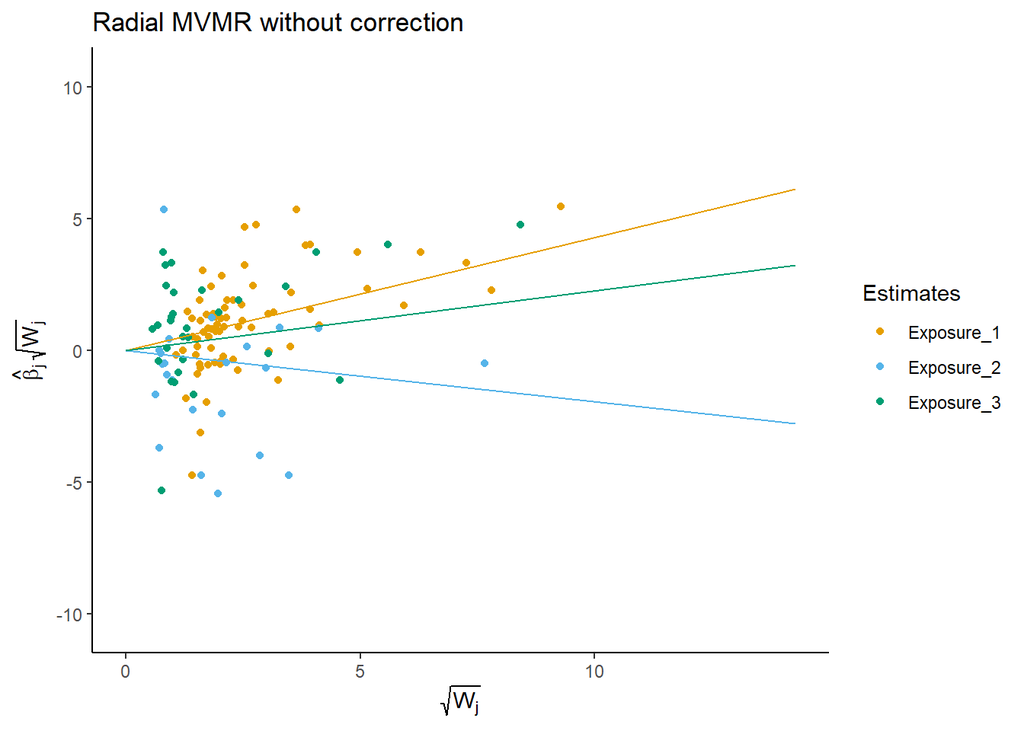

```r
plt_rmvmr <- plot_rmvmr(rmvmr_input, rmvmr = rmvmr_fit)
plt_rmvmr$p1
```

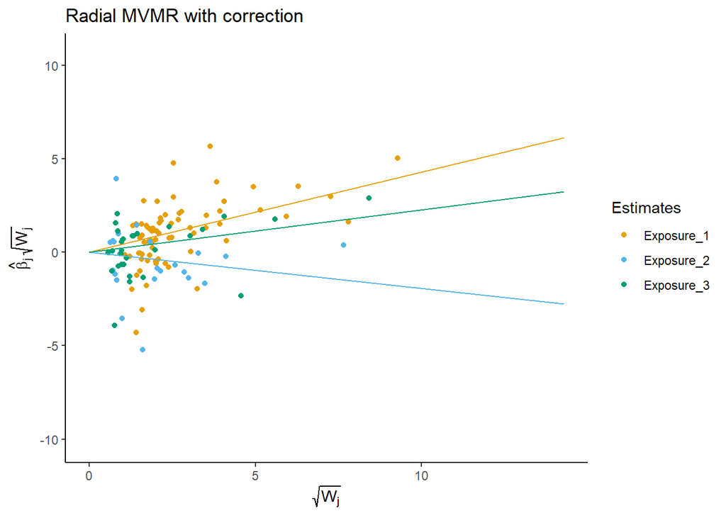

```r
plt_rmvmr$p2
```

- Heterogeneity statistics

```r
pleio_rmvmr <- pleiotropy_rmvmr(rmvmr_input, rmvmr = rmvmr_fit)
pleio_rmvmr$gq
```

```
##            q_statistic      p_value
## Exposure_1    76.37356 2.812609e-01
## Exposure_2    59.58894 8.243650e-06
## Exposure_3    45.88633 1.308596e-02
```

```r
head(pleio_rmvmr$qdat)
```

```
##     snp       wj corrected_beta          qj       qj_p ref_exposure
## 1 snp_1 2.414215      0.3141338 0.031643343 0.85881269   Exposure_1
## 2 snp_2 3.938760      0.3821443 0.008507667 0.92650973   Exposure_1
## 3 snp_3 3.246657     -0.6057993 3.473998077 0.06234046   Exposure_1
## 4 snp_4 2.001191      0.3273484 0.020524059 0.88608310   Exposure_1
## 5 snp_5 9.278826      0.5414293 0.118081748 0.73112437   Exposure_1
## 6 snp_6 1.317671      1.0713541 0.544339092 0.46064001   Exposure_1
```

- Conditional F-statistics for instrument strength (Sanderson, Spiller, and Bowden 2021)

```r
str_rmvmr <- strength_rmvmr(rmvmr_input)
```

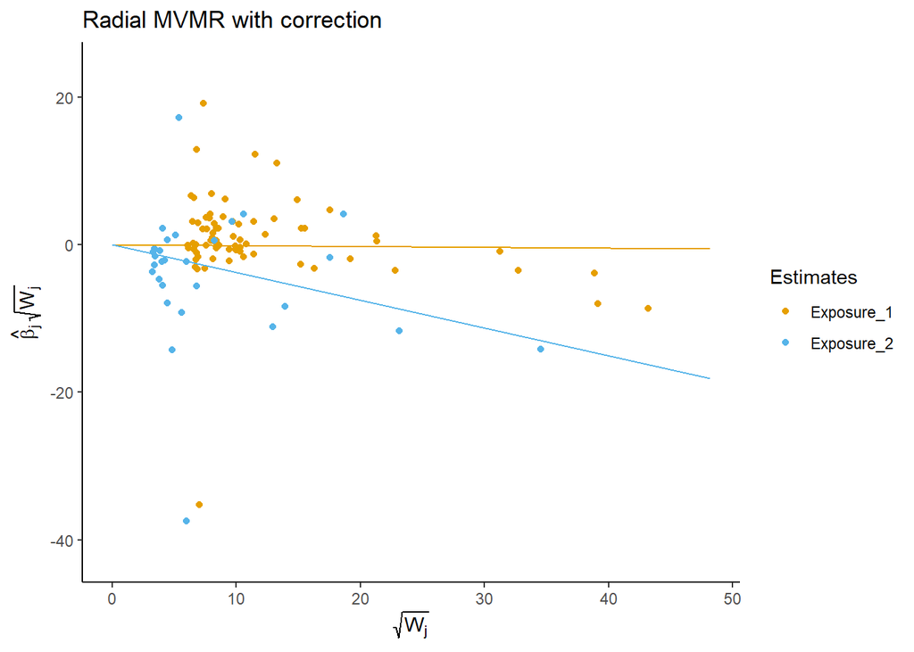

```r
str_rmvmr$plot[[2]]
```

```r
str_rmvmr$qstat[[2]]
```

```
##            q_statistic      p_value
## Exposure_1    335.0602 6.799449e-36
## Exposure_2    371.0830 1.403374e-61
```

## Stata code

- Load the Statamarkdown package to enable Stata code chunks in an R Markdown file

```r
library(Statamarkdown)
```

- Read in the data and create an indicator variable to select observations with *p*-value between the genotype and LDL-C < 10<sup>-8</sup>

```stata
use https://raw.github.com/remlapmot/mrrobust/master/dodata, clear
gen byte sel1 = (ldlcp2 < 1e-8)
```

### Example code using the mrrobust package

- Install the mrrobust package using the github package

```stata
// Note: output suppressed
net install mrrobust, from("https://raw.github.com/remlapmot/mrrobust/master/")
mrdeps
```

- Fit IVW (with fixed effect standard errors)

```stata
mregger chdbeta ldlcbeta [aw=1/(chdse^2)] if sel1==1, ivw fe
```

```
                                                      Number of genotypes = 73
                                      Residual standard error constrained at 1
------------------------------------------------------------------------------
             | Coefficient  Std. err.      z    P>|z|     [95% conf. interval]
-------------+----------------------------------------------------------------
chdbeta      |
    ldlcbeta |   .4815055    .038221    12.60   0.000     .4065938    .5564173
------------------------------------------------------------------------------
```

- Fit MR-Egger reporting I<sup>2</sup><sub>GX</sub> statistic and heterogeneity Q-test

```stata
mregger chdbeta ldlcbeta [aw=1/(chdse^2)] if sel1==1, gxse(ldlcse) heterogi
```

```
                                           Q_GX statistic (weighted) = 3454.26
                                         I^2_GX statistic (weighted) =  97.92%
                                                      Number of genotypes = 73
                                              Residual standard error =  1.548
                Ruecker's Q for heterogeneity; chi2(71) = 170.11 (p =  0.0000)
                             I-squared statistic = 58.3% (95% CI 45.8%, 67.8%)
------------------------------------------------------------------------------
             | Coefficient  Std. err.      z    P>|z|     [95% conf. interval]
-------------+----------------------------------------------------------------
chdbeta      |
       slope |   .6173131   .1034573     5.97   0.000     .4145405    .8200858
       _cons |  -.0087706   .0054812    -1.60   0.110    -.0195136    .0019723
------------------------------------------------------------------------------
```

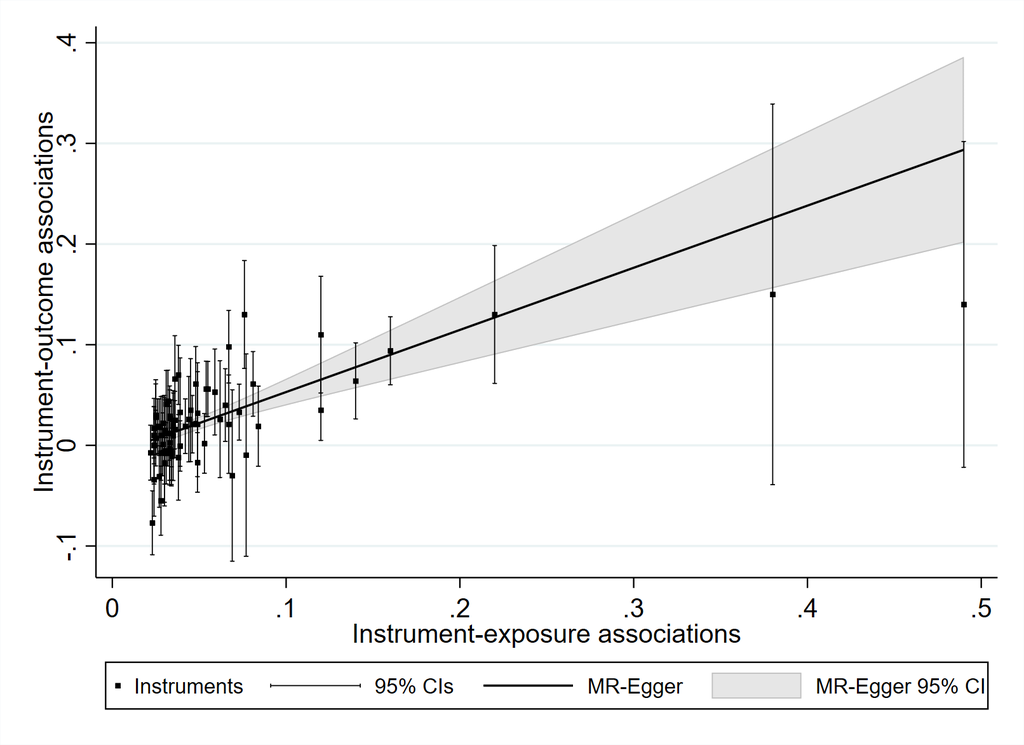

```stata
mreggerplot chdbeta chdse ldlcbeta ldlcse if sel1==1
qui gr export mreggerplot-1.png, replace
```

- Adding the modal and median estimates onto the plot

```
                                                      Number of genotypes = 73
                                                           Replications = 1000
------------------------------------------------------------------------------
             | Coefficient  Std. err.      z    P>|z|     [95% conf. interval]
-------------+----------------------------------------------------------------
        beta |   .4582573   .0633137     7.24   0.000     .3341648    .5823499
------------------------------------------------------------------------------

                                                      Number of genotypes = 73
                                                           Replications = 1000
                                                                     Phi = .25
------------------------------------------------------------------------------
             | Coefficient  Std. err.      z    P>|z|     [95% conf. interval]
-------------+----------------------------------------------------------------
        beta |   .4198713   .2260632     1.86   0.063    -.0232045    .8629471
------------------------------------------------------------------------------
```

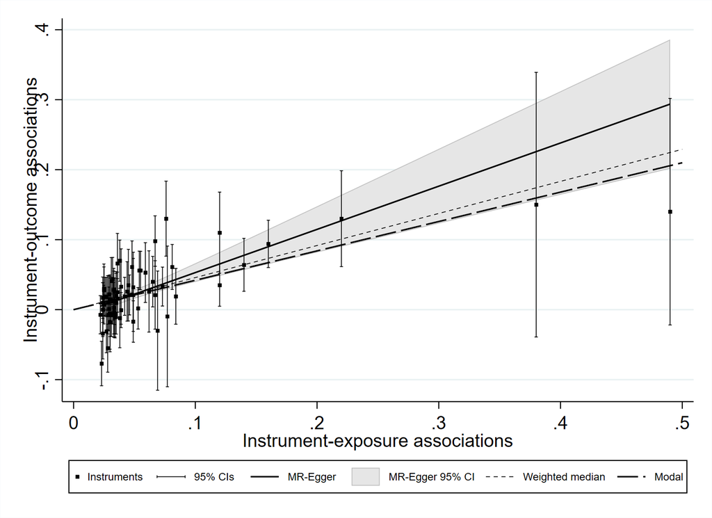

```stata
mreggerplot chdbeta chdse ldlcbeta ldlcse if sel1==1
mrmedian chdbeta chdse ldlcbeta ldlcse if sel1==1, weighted
addplot : function _b[beta]*x if sel1==1, ///
  range(0 0.5) lc(gs0) lp(shortdash) lw(vthin)
mrmodal chdbeta chdse ldlcbeta ldlcse if sel1==1, phi(.25)
addplot : function _b[beta]*x if sel1==1, ///
  range(0 0.5) lc(gs0) lp(longdash) ///
  legend(order(5 "Instruments" ///
               4 "95% CIs" 3 "MR-Egger" 2 "MR-Egger 95% CI" ///
               6 "Weighted median" 7 "Modal") ///
        rows(1) si(vsmall) symx(*.5))
qui gr export mreggerplot-2.png, replace
```

- Fit and MVMR model with phenotypes LDL-c and HDL-c (Burgess, Dudbridge, and Thompson 2015).

```stata
mvmr chdbeta ldlcbeta hdlcbeta [aw=1/(chdse^2)] if sel1==1
```

```
                                                      Number of genotypes = 73
                                                      Number of phenotypes = 2
                                                Standard errors: Random effect
                                              Residual standard error =  1.514
------------------------------------------------------------------------------
             | Coefficient  Std. err.      z    P>|z|     [95% conf. interval]
-------------+----------------------------------------------------------------
chdbeta      |
    ldlcbeta |   .4670719   .0581901     8.03   0.000     .3530214    .5811224
    hdlcbeta |  -.2930048   .1211822    -2.42   0.016    -.5305175   -.0554921
------------------------------------------------------------------------------
```

- Additionally include a third phenotype – triglycerides.

```stata
mvmr chdbeta ldlcbeta hdlcbeta tgbeta [aw=1/(chdse^2)] if sel1==1
```

```
                                                      Number of genotypes = 73
                                                      Number of phenotypes = 3
                                                Standard errors: Random effect
                                              Residual standard error =  1.490
------------------------------------------------------------------------------
             | Coefficient  Std. err.      z    P>|z|     [95% conf. interval]
-------------+----------------------------------------------------------------
chdbeta      |
    ldlcbeta |     .42862   .0609661     7.03   0.000     .3091286    .5481113
    hdlcbeta |  -.1941989   .1308289    -1.48   0.138    -.4506189    .0622211
      tgbeta |   .2260456   .1232828     1.83   0.067    -.0155842    .4676755
------------------------------------------------------------------------------
```

- Report the Q<sub>A</sub> statistic for instrument validity and the conditional F-statistics for instrument strength for each phenotype (Sanderson et al. 2019; Sanderson, Spiller, and Bowden 2021).

```stata
mvmr chdbeta ldlcbeta hdlcbeta tgbeta [aw=1/(chdse^2)] if sel1==1, gxse(ldlcse hdlcse tgse)
```

```
> e hdlcse tgse)

                                                      Number of genotypes = 73
                                                      Number of phenotypes = 3
                                                Standard errors: Random effect
                                              Residual standard error =  1.490
------------------------------------------------------------------------------
             | Coefficient  Std. err.      z    P>|z|     [95% conf. interval]
-------------+----------------------------------------------------------------
chdbeta      |
    ldlcbeta |     .42862   .0609661     7.03   0.000     .3091286    .5481113
    hdlcbeta |  -.1941989   .1308289    -1.48   0.138    -.4506189    .0622211
      tgbeta |   .2260456   .1232828     1.83   0.067    -.0155842    .4676755
------------------------------------------------------------------------------
 Q_A statistic for instrument validity; chi2(70) = 152.88 (p =  0.0000)
 Conditional F-statistics for instrument strength:
 F_x1 = 130.31   (ldlcbeta)
 F_x2 = 36.29    (hdlcbeta)
 F_x3 = 40.44    (tgbeta)
```

- Fit an MVMR-Egger regression (Rees, Wood, and Burgess 2017), orienting the model with respect to the first phenotype in the main *varlist*.

```stata
mrmvegger chdbeta ldlcbeta hdlcbeta tgbeta [aw=1/(chdse^2)] if sel1==1
```

```
                                       MVMR-Egger model oriented wrt: ldlcbeta
                                                      Number of genotypes = 73
                                                      Number of phenotypes = 3
                                              Residual standard error =  1.469
------------------------------------------------------------------------------
             | Coefficient  Std. err.      z    P>|z|     [95% conf. interval]
-------------+----------------------------------------------------------------
chdbeta      |
    ldlcbeta |   .5672993   .1002611     5.66   0.000      .370791    .7638075
    hdlcbeta |  -.1364113   .1332727    -1.02   0.306    -.3976209    .1247983
      tgbeta |   .2739803   .1246927     2.20   0.028     .0295871    .5183735
       _cons |  -.0093655   .0054187    -1.73   0.084     -.019986     .001255
------------------------------------------------------------------------------
```

We can also orient the model with respect to HDL-C.

```stata
mrmvegger chdbeta ldlcbeta hdlcbeta tgbeta [aw=1/(chdse^2)] if sel1==1, orient(2)
```

```
> t(2)

                                       MVMR-Egger model oriented wrt: hdlcbeta
                                                      Number of genotypes = 73
                                                      Number of phenotypes = 3
                                              Residual standard error =  1.501
------------------------------------------------------------------------------
             | Coefficient  Std. err.      z    P>|z|     [95% conf. interval]
-------------+----------------------------------------------------------------
chdbeta      |
    ldlcbeta |   .4286398   .0614056     6.98   0.000      .308287    .5489926
    hdlcbeta |  -.1989637   .1541909    -1.29   0.197    -.5011723    .1032449
      tgbeta |   .2256794   .1243221     1.82   0.069    -.0179875    .4693463
       _cons |   .0002155   .0036218     0.06   0.953     -.006883    .0073141
------------------------------------------------------------------------------
```

Or we can orient the model with respect to triglycerides.

```stata
mrmvegger chdbeta ldlcbeta hdlcbeta tgbeta [aw=1/(chdse^2)] if sel1==1, orient(3)
```

```
> t(3)

                                         MVMR-Egger model oriented wrt: tgbeta
                                                      Number of genotypes = 73
                                                      Number of phenotypes = 3
                                              Residual standard error =  1.499
------------------------------------------------------------------------------
             | Coefficient  Std. err.      z    P>|z|     [95% conf. interval]
-------------+----------------------------------------------------------------
chdbeta      |
    ldlcbeta |   .4203073   .0660026     6.37   0.000     .2909447      .54967
    hdlcbeta |  -.1903089   .1321536    -1.44   0.150    -.4493252    .0687075
      tgbeta |   .2065651   .1365427     1.51   0.130    -.0610537     .474184
       _cons |   .0013499    .003951     0.34   0.733    -.0063939    .0090936
------------------------------------------------------------------------------
```

## Session information for reproducibility

### R session information

```r
library(sessioninfo)
```

[output not shown]

### Stata session information

```stata
about
ado describe mrrobust
```

```
Stata/MP 17.0 for Windows (64-bit x86-64)
Revision 08 Mar 2023
Copyright 1985-2021 StataCorp LLC

Total physical memory:       32.00 GB
Available physical memory:   15.29 GB

Stata license: Unlimited-user 2-core network, expiring 21 Jan 2024
Serial number: 501709378202
  Licensed to: Tom Palmer
               University of Bristol


-------------------------------------------------------------------------------
[47] package mrrobust from https://raw.githubusercontent.com/remlapmot/mrrobust
> /master
-------------------------------------------------------------------------------

TITLE
      'mrrobust': Stata package for two-sample Mendelian randomization analyses

DESCRIPTION/AUTHOR(S)
      Author: Tom Palmer
      Distribution-Date: 20210917

INSTALLATION FILES
      m\mrmedian.ado
      m\mrmedian.sthlp
      m\mrmedianobs.ado
      m\mrmedianobs_work.ado
      m\mrmedianobs.sthlp
      m\mregger.ado
      m\mregger.sthlp
      m\mrrobust.sthlp
      m\mreggerplot.ado
      m\mreggerplot.sthlp
      m\mrmodal.ado
      m\mrmodal.sthlp
      m\mrratio.ado
      m\mrratio.sthlp
```

[output cut: 15 more lines]

```
      m\mrmvivw.ado
      m\mrmvivw.sthlp
      m\mvivw.ado
      m\mvivw.sthlp
      m\mvmr.ado
      m\mvmr.sthlp
      m\mrmvegger.ado
      m\mrmvegger.sthlp
      m\mrleaveoneout.ado
      m\mrleaveoneout.sthlp
      m\mrrobust-author.ihlp

INSTALLED ON
      17 Feb 2023
-------------------------------------------------------------------------------
```

## References

Burgess, S, F Dudbridge, and SG Thompson. 2015. “Multivariable Mendelian randomization: the use of pleiotropic genetic variants to estimate causal effects.” *American Journal of Epidemiology* 181: 251--260. https://doi.org/10.1093/aje/kwu283.

Rees, J, A Wood, and S Burgess. 2017. “Extending the MR-Egger method for multivariable Mendelian randomization to correct for both measured and unmeasured pleiotropy.” *Statistics in Medicine* 36: 4705–18. https://doi.org/10.1002/sim.7492.

Sanderson, E, G Davey Smith, F Windmeijer, and J Bowden. 2019. “An examination of multivariable Mendelian randomization in the single-sample and two-sample summary data settings.” *International Journal of Epidemiology* 48: 713–27. https://doi.org/10.1093/ije/dyy262.

Sanderson, E, W Spiller, and J Bowden. 2021. “Testing and Correcting for Weak and Pleiotropic Instruments in Two-Sample Multivariable Mendelian Randomization.” *Statistics in Medicine*. https://doi.org/10.1002/sim.9133.